# Assignment 4

Eric Spinelli 799827

## Esercizio 1

Si rappresenta graficamente il problema proposto, a partire dall’albero decisionale costruito con Radiant e salvato come file .yaml

```r
#si importano le library d'interesse
library(radiant.model)
library(yaml)
```

```r
#si assegna il file .yaml ad una variabile
PAL_yaml<-'file:///C:/Users/Eric/Desktop/PAL_chips_contract_dtree_input.yaml'

#si applica la funzione dtree che ricrea il decision tree
tree<-dtree(yaml.load_file(PAL_yaml), opt = "max")

#si plotta l'albero decisionale
plot(
  tree,
  symbol = "$",
  dec = 2,
  final = FALSE,
  orient = "LR"
)
```

[interactive chart not shown]

L’albero ha un primo nodo di tipo decisionale, per cui l’azienda DM sceglie se acquistare tutte le 500000 chips da IM, metà da IM e metà da KR, o tutte da KR. I nodi successivi sono chance node, che dipendono prima dalla probabilità che venga applicata o meno la tassa a KR, e poi dalla probabilità di 1/3 ciascuna che la tassa sia una maggiorazione del 50%, 100% o 200% del prezzo iniziale.

## Esercizio 2

Si computa l’Expected Value ad ogni passaggio a partire dagli estremi e procedendo verso la radice dell’albero. L’EV è utilizzato come criterio decisionale, se pur non tiene conto dell’attitudine al rischio.

```r
#si assegna le probabilità usate nell'albero decisionale rispettivamente per 50%, 100%, 200% di sovrattassa per KR
p_50TAX<-1/3
p_100TAX<-1/3
p_200TAX<-1/3

#si assegna la probabilità di subire o meno la tassa da parte di KR
p_TAX<-0.6
p_NOTAX<-0.4

#si assegna il payoff della scelta di IM direttamente dall'albero
IM<-tree$yl$`500k IM`$payoff

#si assegnano i payoff direttamente dall'albero decisionale rispetto alla scelta mista di IM e KR, nel caso dell'applicazione della tassa
IM_KR_50TAX<-tree$yl$`250k IM, 250k KR`$TAX$`_50% PLUS TAX`$payoff
IM_KR_100TAX<-tree$yl$`250k IM, 250k KR`$TAX$`_100% PLUS TAX`$payoff
IM_KR_200TAX<-tree$yl$`250k IM, 250k KR`$TAX$`_200% PLUS TAX`$payoff

#e nel caso di non applicazione della tassa
IM_KR_NOTAX<-tree$yl$`250k IM, 250k KR`$`NO TAX`$payoff

#si assegnano i payoff direttamente dall'albero decisionale rispetto alla scelta di KR, nel caso dell'applicazione della tassa
KR_50TAX<-tree$yl$`500k KR`$TAX$`_50% PLUS TAX`$payoff
KR_100TAX<-tree$yl$`500k KR`$TAX$`_100% PLUS TAX`$payoff
KR_200TAX<-tree$yl$`500k KR`$TAX$`_200% PLUS TAX`$payoff

#e nel caso di non appllicazione della tassa
KR_NOTAX<-tree$yl$`500k KR`$`NO TAX`$payoff
```

```r
#si computa EV per le diramazioni più estreme
EV_B1<-p_50TAX*IM_KR_50TAX+p_100TAX*IM_KR_100TAX+p_200TAX*IM_KR_200TAX
EV_B2<-p_50TAX*KR_50TAX+p_100TAX*KR_100TAX+p_200TAX*KR_200TAX

EV_B1
```

```
## [1] -1833333
```

```r
EV_B2
```

```
## [1] -1625000
```

```r
#si computa EV per le prime diramazioni
EV_A2<-p_TAX*EV_B1+p_NOTAX*IM_KR_NOTAX
EV_A3<-p_TAX*EV_B2+p_NOTAX*KR_NOTAX

EV_A2
```

```
## [1] -1600000
```

```r
EV_A3
```

```
## [1] -1275000
```

Ne risulta che la scelta ottimale è quella di acquistare 500000 chips direttamente dall’azienda KR, questo perchè la scelta risulta un EV maggiore, e quindi un costo minore. La seconda scelta sarebbe quella di acquistare soltanto da IM, che riporta un EV intermedio. La terza ed ultima scelta sarebbe quella di acquistare sia da IM che da KR.

Si confronta ora i risultati ottenuti con quelli risolti con l’albero decisionale con Radiant

```r
plot(
  tree,
  symbol = "$",
  dec = 2,
  final = TRUE,
  orient = "LR",
  width = "900px"
)
```

[interactive chart not shown]

I risultati ottenuti da Radiant sono gli stessi

## Esercizio 3

La Sensitivity Analysis consente di studiare come al variare di alcune variabili possano cambiare le scelte ottimali da prendere. Nel nostro caso specifico le variabili considerate riguardano la probabilità con cui KR subirà o meno la tassa.

```r
#A è la probabilità che KR subirà la tassa
#B è la probabilità che KR non subirà la tassa
sensitivity(
  tree,
  vars = c('A 0 1 0.1','B 0 1 0.1'),
  decs = c('500k IM','250k IM, 250k KR','500k KR'),
  custom = FALSE
)
```

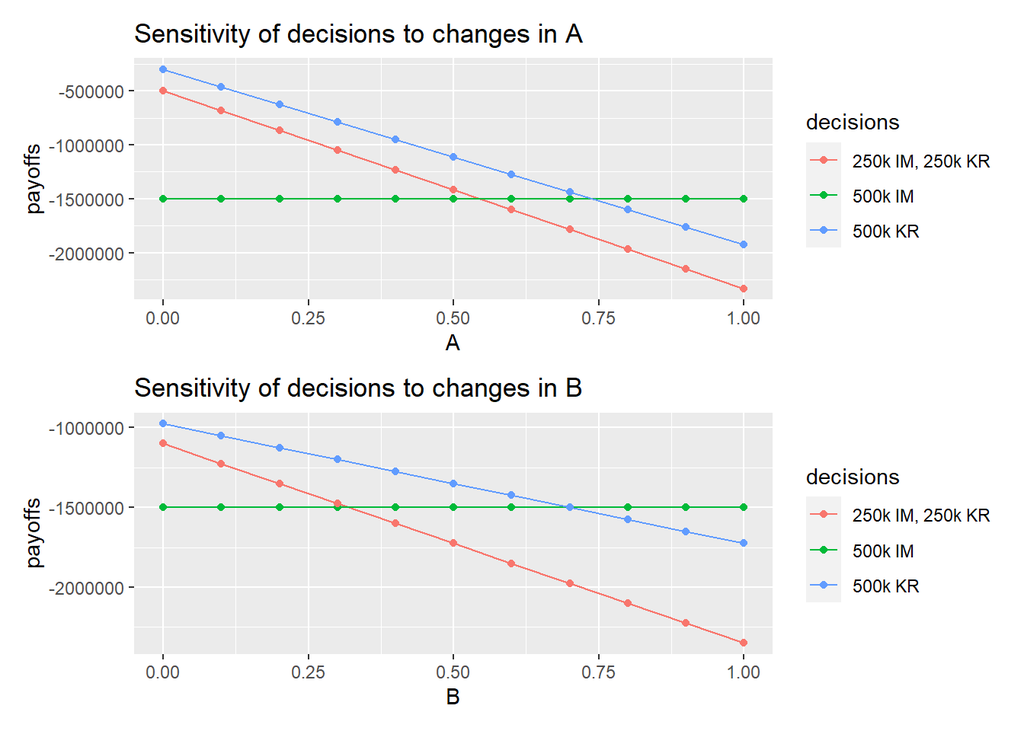

Dal grafico possiamo osservare che quando il valore di A supera 0.75 circa, la scelta di acquistare 500000 chips da IM diventa più interessante. Invece all’aumentare di B, quando il suo valore supera circa 0.7, la scelta acquistare le 500000 chips da IM diventa più interessante mentre al valore di appena 0.3 circa risulta già più interessante acquistare solo da IM invece che da entrambe le aziende.

## Esercizio 4

Quando si tratta di Risk Attitude diventa necessario prendere in considerazione la funzione di utilità. Essa, a seconda della sua forma concava o convessa, fornisce indicazioni rispetto alla propensione al rischio (forma convessa) o avversione al rischio (forma concava) da parte del decsion maker.

Nel caso in questione abbiamo a che fare con una funzione esponenziale, la cui forma concava è indice che il decision maker è avverso al rischio. La Risk Tolerance è un indice che al suo crescere esprime maggiore avversione al rischio. Nel nostro caso R=750000.

La funzione di utilità si presenta come:
$$U(x)=1-e^{-x/R}$$

```r
#si imposta la funzione di utilità
R<-750000
UFExp <- function(X, R) {
  res <- 1- exp(-X/R)
  return(res)
}
```

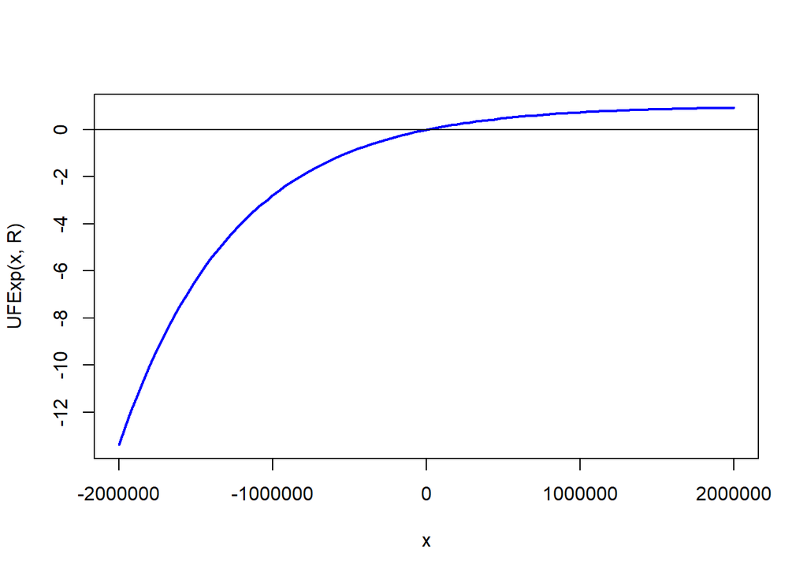

```r
#si plotta il grafico della funzione
curve(UFExp(x,R),from=-2000000,to=2000000,lwd=2,col='blue')
abline(h=0)
```

A partire dalla formulazione della funzione di utilità, si computano i payoff rispetto alla funzione e si calcolano le Expected Utility che equivale al valore atteso rispetto alla funzione di utilità. Da quest’ultimo si può computare il Certainty Equivalent.

```r
#funzione di utilità applicata al payoff di IM
UF_IM<-round(UFExp(IM,R),4)

CE_IM<- -R*log(1-UF_IM)
#funzione di utilità applicata ai casi in cui viene applicata una tassa a KR e si scelgono entrambe le aziende
UF_IM_KR50<-round(UFExp(IM_KR_50TAX,R),4)
UF_IM_KR100<-round(UFExp(IM_KR_100TAX,R),4)
UF_IM_KR200<-round(UFExp(IM_KR_200TAX,R),4)

#Expected Utility rispetto ai valori appena calcolati della funzione di utilità
EU_IM_KR_TAX<-round(UF_IM_KR50*(1/3)+UF_IM_KR100*(1/3)+UF_IM_KR200*(1/3),4)

#funzione di ultilità calcolata nel caso non venga applicata alcuna tassa su KR e si scelgono entrambe le aziende
UF_IM_KR_NOTAX<-round(UFExp(IM_KR_NOTAX,R),4)

#Expected Utility calcolata rispetto alla scelta di contrattare con entrambe le aziende
EU_IM_KR<-round(EU_IM_KR_TAX*0.6+UF_IM_KR_NOTAX*0.4,4)

#Rispettivo Cenrtainty Equivalent
CE_IM_KR<- -R*log(1-EU_IM_KR)

#funzione di utilità calcolata nel caso in cui venga applicata una tassa a KR ed essa è l'azienda scelta
UF_KR50<-round(UFExp(KR_50TAX,R),4)
UF_KR100<-round(UFExp(KR_100TAX,R),4)
UF_KR200<-round(UFExp(KR_200TAX,R),4)

#Expected Utility computata rispetto ai valori appena calcolati dalla funzione di utilità
EU_KR_TAX<-round(UF_KR50*(1/3)+UF_KR100*(1/3)+UF_KR200*(1/3),4)

#funzione di utilità computata nel caso in cui non venga applicata alcuna tassa a KR ed essa è l'azienda scelta
UF_KR_NOTAX<-round(UFExp(KR_NOTAX,R),4)

#Expected Utility calcolata rispetto alla scelta di KR
EU_KR<-round(EU_KR_TAX*0.6+UF_KR_NOTAX*0.4,4)

#Rispettivo Certainty Equivalent
CE_KR<- -R*log(1-EU_KR)
```

Di seguito i valori calcolati dalla funzione di utilità

```
## [1] "La funzione di utilità applicata al payoff di IM risulta: -6.3891"
```

```
## [1] "La funzione di utilità applicata al payoff di IM e KR con tassa antidumping del 50% risulta: -6.3891"
```

```
## [1] "La funzione di utilità applicata al payoff di IM e KR con tassa antidumping del 100% risulta: -9.3123"
```

```
## [1] "La funzione di utilità applicata al payoff di IM e KR con tassa antidumping del 200% risulta: -19.0855"
```

```
## [1] "La funzione di utilità applicata al payoff di IM e KR senza applicazione della tassa risulta: -4.2945"
```

```
## [1] "La funzione di utilità applicata al payoff di KR con tassa antidumping del 50% risulta: -3.4817"
```

```
## [1] "La funzione di utilità applicata al payoff di KR con tassa antidumping del 100% risulta: -6.3891"
```

```
## [1] "La funzione di utilità applicata al payoff di KR con tassa antidumping del 200% risulta: -19.0855"
```

```
## [1] "La funzione di utilità applicata al payoff di KR senza applicazione della tassa risulta: -1.7183"
```

Si riporta ora i valori della funzione di utilità in un albero decisionale per vedere come cambia la decisione nel nostro caso di avversione al rischio con R=750000

```r
PAL_yaml2<-'file:///C:/Users/Eric/Desktop/PAL_chips_contract_dtree_input_3.yaml'
tree2<-dtree(yaml.load_file(PAL_yaml2), opt = "max")
plot(
  tree2,
  dec = 4,
  final = TRUE,
  orient = "LR",
  width = "900px"
)
```

[interactive chart not shown]

Si ripotano i valori dell’Expected Utility computati precedentemente e si confrontano i risultati

```
## [1] "Expected Utility relativa all' acquisto da IM: -6.3891"
```

```
## [1] "Expected Utility relativa all'acquisto da IM e KR: -8.6752"
```

```
## [1] "Expected Utility relativa all'acquisto solo da KR -6.4786"
```

I valori corrispondono. La scelta migliore da fare utilizzando questa funzione di utilità avversa al rischio è di acquistare direttamente dall’azienda IM. La seconda scelta migliore è quella di acquistare direttamente da KR. L’ultima scelta è quella di acquistare da entrambe le aziende.

Di seguito si riportano i risultati del Certainty Equivalent, i quali confermano le scelte appena descritte.

```
## [1] "Certainty Equivalent rispetto alla scelta di IM: -1500004.456"
```

```
## [1] "Certainty Equivalent rispetto alla scelta di IM e KR: -1702174.4329"
```

```
## [1] "Certainty Equivalent rispetto alla scelta di KR: -1509034.2065"
```

## Esercizio 5

Si suppone che il sovrapprezzo da parte dell’azienda italiana venga effettuato soltanto nel caso in cui si recede al contratto con l’azienda coreana, esclusivamente per la quantità recessa. per questa ragione al primo nodo non si considerano i sovrapprezzi dell’azienda italiana nel caso delle 3 sovrattasse. Inoltre è considerata la penale in caso di recesso dai contratti con l’azienda KR.

```r
#il nuovo albero decisionale si presenta così
PAL_yaml3<-'file:///C:/Users/Eric/Desktop/PAL_es_5_dtree_input.yaml'
tree3<-dtree(yaml.load_file(PAL_yaml3), opt = "max")

plot(
  tree3,
  symbol = "$",
  dec = 2,
  final = TRUE,
  orient = "LR",
  width = "900px"
)
```

[interactive chart not shown]

Da come si può osservare dall’albero decisionale, secondo la tecnica dell’ Expected Value, la decisione migliore da prendere consiste nell’acquistare direttamente le 500000 chips dall’azienda KR. Se viene imposta la tassa antidumping al 50% o al 100% conviene accettare l’offerta dell’azienda coreana, mentre se la tassa antidumping è imposta al 200% conviene acquistare dall’azienda italiana IM pagando la pendale e il sovrapprezzo.

## Esercizio 6

La Perfect Information è considerata un upper bound del risultato finale reale. Per inserire l’ipotesi di Perfect Information nell’albero decsionale e computarne il massimo prezzo si stabilisce che i rami che caratterizzano l’informazione siano equiprobabili, nel nostro caso il fatto che venga imposta o meno la tassa antidumping. Questo accade perchè soltanto quando l’informazione verrà acquistata allora si verrà a conoscenza dell’informazione.

Di seguito si riporta l’albero decisionale integrato con il ramo di presenza di informazione.

```r
PAL_yaml4<-'file:///C:/Users/Eric/Desktop/PAL_es_6_dtree_input.yaml'
tree4<-dtree(yaml.load_file(PAL_yaml4), opt = "max")

plot(
  tree4,
  symbol = "$",
  dec = 2,
  final = TRUE,
  orient = "LR",
  width = "900px"
)
```

[interactive chart not shown]

Di conseguenza si stabilisce il prezzo massimo che si sarebbe disposti a pagare per ottenere l’informazione perfetta.

```r
#dall'albero decisionale si riporta il valore atteso dell'ottenere l'informazione
EV_INFO<- -1137500.21

#dall'albero decisionale si riporta il valore atteso senza ottenere l'informazione
EV_NOINFO<- -1215000.25

PREZZO_INFO<- EV_INFO-EV_NOINFO
```

```
## [1] "Il prezzo massimo che si è disposti a pagare per ottenere l'informazione è: 77500.04"
```